# 📌 Análisis de Secuencias de *E. coli*

Jafet Arauz

2025-02-28

## Introducción

Este documento resume el análisis realizado en Linux, incluyendo los comandos de Bash creados durante el proceso para mejorar la calidad del analisis de las secuencias BQ, Negative, Positive y Long que se muestran en la siguiente imagen.

**Nota:** Puede ver este informe de manera interactiva en dando click al siguiente enlace. [🔗 Ver informe en HTML](https://jafetarauz16.github.io/Proyecto_analisis_NGS_E_Coli/Jafet_Arauz.html)

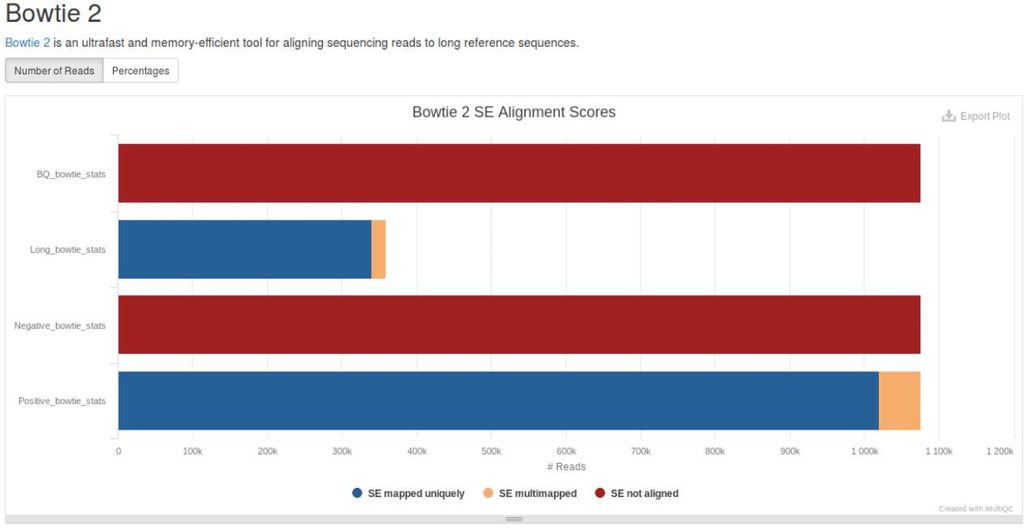

## 1 -**Parte 1 del ejercicio mejorar Negative que habia dado 0% de alineamiento**

### 1.1 Entorno de Trabajo en Linux

```bash
# Fijar el path temporalmemte y verificarlo
st_path="/workspace/NGS_practicals"
echo $st_path

# Configurar canales de conda (el orden es importante)
conda config --add channels defaults
conda config --add channels bioconda
conda config --add channels conda-forge
conda config --set channel_priority strict

# Crear entornos con mamba
mamba env create -f "${st_path}"/env/.environment_NGS.yaml
mamba env create -f "${st_path}"/env/.environment_multiqc.yaml

# cuadno aparezca en la terminal lo siguiente Confirm changes: [Y/n]. escribir : Y o y

# Crear carpeta del proyecto
mkdir Proyecto_analisis_NGS_Ecoli_Jafet_Arauz

# Cambiar el path de trabajo y verificarlo
st_path="/workspace/NGS_practicals/Proyecto_analisis_NGS_Ecoli_Jafet_Arauz"
echo $st_path

# Entrar en la carpeta del proyecto y crear subdirectorios
cd Proyecto_analisis_NGS_Ecoli_Jafet_Arauz
mkdir Data Results Scrips

# Ver ubicación actual
pwd

# Ir a la carpeta Data , crear carpeta Fastq y luego ir a la carpeta Fastq
cd Data
mkdir Fastq
cd Fastq
mkdir Sequences

# Descargar el archivo de datos

wget "https://www.dropbox.com/s/91iqhvmd3ckysju/final_merge_syntetic_reads.fq.gz" \
    -O final_merge_synthetic_reads.fq.gz

# Descomprimir el archivo

gunzip final_merge_synthetic_reads.fq.gz
```

### 1.2 Control de Calidad (QC) con FastQC y MultiQC

```bash
# Activate Conda environment
conda activate env_NGS

# Anlaisis Qc de las seceuncias crudas y revisarlo

fastqc -o . "$st_path/Data/Fastq/final_merge_synthetic_reads.fq"

firefox final_merge_synthetic_reads_fastqc.html
```

*Analisis de control de calidad de las secuencias crudas*

[figure not shown]

```bash
# Extraer las secuencias individualmente de nuestro archvivo .fq y quitar adaotadores
cutadapt \
    -g Positive=^GATACA \
    -g Negative=^AGTAGT \
    -g BQ=^CACACA \
    -g Long=^AAACCC \
    -o Sequences/{name}.fq final_merge_synthetic_reads.fq

# Entrar a la carpeta Secuences y verificar que se generaron los archivos

cd Sequences

# Cambiar de directorio y crear carpeta para guardar el output del qc de las secuencias
# sin adaptadores

cd "${st_path}/Results"
mkdir QC_Raw
cd QC_Raw

# correr el QC de los archivos despues de remover adaptadores
fastqc -o . "$st_path"/Data/Fastq/Sequences/*.fq

en la salida en la terminar veras algo asi  "null" , puedes ignorar sin problema,
porque no  afecta los resultados.

# Revisar el resultado individual de Negative de su QC

firefox Negative_fastqc.html
```

*Analisis de control de calidad de la secuencia Negative despues de* *separarlas secuencias y remover adaptadores*

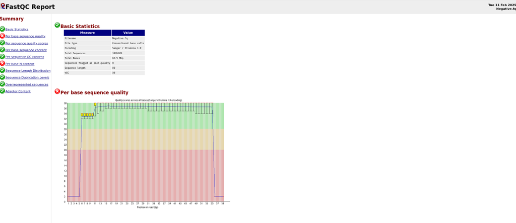

```bash
# Desactivar el enviroment env_NGS y Activar el env_multiqc
conda deactivate
conda activate env_multiqc

#Correr el multiqc

multiqc -o . -n multiqc_report_seq_sin_adaptr.html .

# Abrir el reporte en Firefox. Revisar multiQC
# NOTA Para cerrar firefox "ctr + c" en la terminal.

firefox multiqc_report_seq_sin_adaptr.html

#Observar todos los resultados obtenidos despues de haber
# removido adaptadores y valorar que hacer en el paso del triming
```

### 1.3 Grafico despues de remover adaptadores

[figure not shown]

### 1.4 **Limpieza de Lecturas en base al QC**

```bash
# Cambiar de directorio, crear carpeta para guardar el output de la limpieza de las
# lecturas y entrar a la carpeta

cd "${st_path}/Results"
mkdir Secuences_Trimmed
cd Secuences_Trimmed

# Desactivar el enviroment env_multiqc y activar el env_NGS
conda deactivate
conda activate env_NGS

# ejecutar esta liena de comando mejorada solo a los archivos Negative, Positive
# y Long (BQ se hara en el apartado 2)

echo -e "\n##################################################################"
echo -e " Elaborado por Jafet Arauz | Refinando secuencias con Cutadapt... "
echo -e " Aplicando filtros de calidad y longitud en: Negative, Positive y Long"
echo -e "##################################################################\n"

for file in Negative Positive Long; do
    cutadapt \
        --quality-cutoff 20 \
        --minimum-length 30 \
        --nextseq-trim=20 \
        --trim-n \
        --max-n 0 \
        -o "${file}_cleaned.fq" \
        "$st_path/Data/Fastq/Sequences/${file}.fq"
done

echo -e "\n##################################################################"
echo -e " Refinamiento finalizado con éxito. Archivos guardados en Results/Secuences_Trimmed"
echo -e " Análisis realizado por Jafet Arauz |"
echo -e "##################################################################\n"
```

### 1.5 **Multiqc despues del TRIMMING**

```bash
# Cambiar de directorio, crear carpeta para guardar el output del multiqc de las
# lecturas trimeadas  y entrar a la carpeta

cd "${st_path}/Results"
mkdir QC_Cleaned
cd QC_Cleaned

# Ejecutar FastQC en los archivos trimmed
fastqc -o . "$st_path/Results/Secuences_Trimmed/"*.fq

# Desactivar el enviroment env_NGS y Activar el env_multiqc
conda deactivate
conda activate env_multiqc

# Ejecutar MultiQC para agrupar los reportes
multiqc -f -o . -n "multiqc_cleaned_report" .

# Abrir el reporte en Firefox. Revisar multiQC
# NOTA Para cerrar firefox "ctr + c" en la terminal.
firefox multiqc_cleaned_report.html
```

*Reporte de control de calidad despues de hacer trimming en base al QC*

[figure not shown]

### 1.6 **Alineamiento mejorado con Bowtie2**

```
    **para mejorar Negative**
```

```bash
# Pasos previos antes de hacer el alineamineto

# Desactivar el enviroment y cambiar al env_NGS

conda deactivate
conda activate env_NGS

cd "$st_path"

# Crear carpeta Genomes_reference para guarda genoma de referencia e indexarlo y entrar en la carpeta

mkdir Genomes_reference
cd Genomes_reference

# copiar archivos

cp /workspace/NGS_practicals/course_materials/genomes/AFPN02.1/AFPN02.1_merge.fasta \
   /workspace/NGS_practicals/course_materials/genomes/AFPN02.1/AFPN02.1_merge.fasta.fai .

# Create Bowtie2 genome index
bowtie2-build AFPN02.1_merge.fasta AFPN02.1_merge

# Cambiar de directorio

cd "${st_path}/Results"

#Crear carpeta para alamcenar resultados del aligment y entar en es carpeta
mkdir Aligned_Sequences
cd Aligned_Sequences

# verificar la ayuda de bowtie2
bowtie2 --help

# Correr  Bowtie2  para Long_cleaned Negative_cleaned Positive_cleaned
# importante ver que este activado el enviroment env_NGS

echo -e "\n##################################################################"
echo -e " Elaborado por Jafet Arauz | Iniciando alineamiento con Bowtie2 "
echo -e "##################################################################\n"

for filename in Long_cleaned Negative_cleaned Positive_cleaned; do
    echo -e "\nProcesando muestra: ${filename}...\n"

    bowtie2 --very-sensitive --no-unal --end-to-end --no-mixed --no-discordant -k 10 \
        -x "$st_path/Genomes_reference/AFPN02.1_merge" \
        -U "$st_path/Results/Secuences_Trimmed/${filename}.fq" \
        -S "${filename}.sam" \
        2> "${filename}_bowtie_stats.txt"

    echo -e " Alineamiento completado para: ${filename} "
    echo -e "- Archivo SAM: ${filename}.sam"
    echo -e "- Estadísticas: ${filename}_bowtie_stats.txt"
    echo -e "-------------------------------------------------------------\n"
done

echo -e "\n##################################################################"
echo -e " ¡Bowtie2 finalizado con éxito para todas las muestras! "
echo -e " Resultados guardados en: "
echo -e " $st_path/Results/Aligned_Sequences/"
echo -e "##################################################################\n"

# Desactivar el enviroment env_NGS y Activar el env_multiqc
 conda deactivate
 conda activate env_multiqc

# Ejecutar multiqc y observar el resultado tiene este nombre por que no incluye BQ.fq
multiqc -n "multiqc_aligned_partial" .

firefox multiqc_aligned_partial.html
```

*Resultados del alineamiento con los parametros –very-sensitive, y –end-to-end*

[figure not shown]

### 1.7 **samtools stats y flagstats para la parte 1**

```bash
# Desactivar el enviroment env_multiqc y activar el env_NGS
conda deactivate
conda activate env_NGS

#Ejecutar esta linea de comando para ejecutar samtools

for sample in Long_cleaned Negative_cleaned Positive_cleaned; do
    echo "Procesando muestra: ${sample}..."
    samtools view -bS "${sample}.sam" -o "${sample}.bam"
    samtools sort "${sample}.bam" -o "${sample}_sorted.bam"
    samtools index "${sample}_sorted.bam"
    samtools stats "${sample}_sorted.bam" > "${sample}_stats.txt"
    samtools flagstat "${sample}_sorted.bam" > "${sample}_flagstat.txt"

    echo "Procesamiento completado para: ${sample}"
    echo "Archivos generados:"
    echo "- ${sample}.bam"
    echo "- ${sample}_sorted.bam"
    echo "- ${sample}_sorted.bam.bai"
    echo "- ${sample}_stats.txt"
    echo "- ${sample}_flagstat.txt"
    echo "----------------------------------------"
done

# Desactivar el enviroment env_NGS y Activar el env_multiqc
conda deactivate
conda activate env_multiqc

# Ejecutar multiqc y observar el resultado tiene este nombre por que no incluye BQ.fq
multiqc -o . -n "multiqc_aligned_partial_v2" .

firefox multiqc_aligned_partial_v2.html
```

*Estadisticas obtenidas del alineamiento*

[figure not shown]

### 1.8 **Segunda opcion de alineamiento**

```bash
# Desactivar el enviroment y cambiar al env_NGS
conda deactivate
conda activate env_NGS

# Ejecutar otro alineamiento para Negative con otros parametros

echo -e "\n##################################################################"
echo -e " Elaborado por Jafet Arauz | 2da Opcion de alineamiento de Negative "
echo -e "                    con Bowtie2... "
echo -e "##################################################################\n"

bowtie2 --fast --no-unal --local --no-mixed --no-discordant -k 10 \
    -x "$st_path/Genomes_reference/AFPN02.1_merge" \
    -U "$st_path/Results/Secuences_Trimmed/Negative_cleaned.fq" \
    -S "Negative_cleaned_v2.sam" \
    2> "Negative_cleaned_bowtie_stats_v2.txt"

echo -e "\n##################################################################"
echo -e " Alineamiento de Negative completado con éxito. Resultados guardados en: $(pwd)"
echo -e "##################################################################\n"

# Ahora usar samtols para obtener mas metricas del resultados de este alineamiento

echo "Procesando muestra: Negative_cleaned_v2..."
samtools view -bS "Negative_cleaned_v2.sam" -o "Negative_cleaned_v2.bam"
samtools sort "Negative_cleaned_v2.bam" -o "Negative_cleaned_v2_sorted.bam"
samtools index "Negative_cleaned_v2_sorted.bam"
samtools stats "Negative_cleaned_v2_sorted.bam" > "Negative_cleaned_v2_stats.txt"
samtools flagstat "Negative_cleaned_v2_sorted.bam" > "Negative_cleaned_v2_flagstat.txt"

echo "Procesamiento completado para: Negative_cleaned_v2"
echo "Archivos generados:"
echo "- Negative_cleaned_v2.bam"
echo "- Negative_cleaned_v2_sorted.bam"
echo "- Negative_cleaned_v2_sorted.bam.bai"
echo "- Negative_cleaned_v2_stats.txt"
echo "- Negative_cleaned_v2_flagstat.txt"
echo "----------------------------------------"

# Desactivar el enviroment env_NGS y Activar el env_multiqc
conda deactivate
conda activate env_multiqc

# Ejecutar multiqc para comparar solo los dos tipos de alineamiento con Negative
multiqc -o . -n "multiqc_Negative_comparison_aligmnt" Negative_cleaned_bowtie_stats.txt Negative_cleaned_bowtie_stats_v2.txt

firefox multiqc_Negative_comparison_aligmnt.html
```

*Compracaion de dos tipos de alineamiento, uno con –local* *, -fast (Negative_cleaned_bowtie_stats_v2.txt) y otro con* *–very-sensitive –end-to-end (Negative_cleaned_bowtie_stats.txt)*

[figure not shown]

*Outputs del segundo alineamineto*

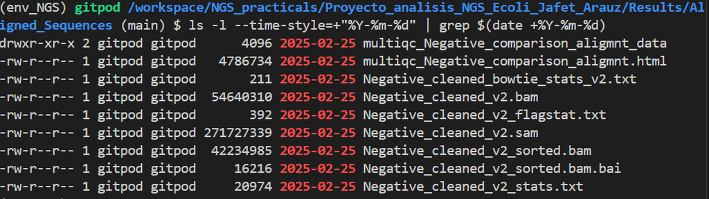

### 1.9 Respuestas a preguntas de la parte 1 del ejercicio

#### 1.9.1 **Explicacion de que habia hecho que las lecturas salieran mal en principio**

En princio las lecturas salian de mala calidad por preesencia de adaptadores, errores durante la secueciacion, longitudes variables y poca calidad en algunos nucleotidos. Esto al principio no se corrigio correctamente y por eso que los resultados del primer alineamiento deficiente.Esto se mejoro al modificar bien los parametros de el trimming y liempieza de las lecturas y despues se optimizo los parametros del alineamineto.

#### 1.9.2 **Explicacion por que decidi esta opcion de alienamiento**

Decidi esta opcion de alineamiento por que era la que mejor ajustaba las secuencias en base a los resultados obtenidos del QC permitiedome obtener los mejores resultados en el alineamiento con Bowtie2, ademas Bowtie2 ofrece una mayor sensibilidad y precision en alineamientos de secuencias cortas.

Ademas como ya habia retirado previamente los adaptadores y habia realizado el trimming en base a los resultados del control de calidad decidi usar –very-sensitive –end-to-end , en primera por que –end-to-end no hace recorte a los extremos de las secuencias , por el contrario al usar –local este hace recorte a los extremos en caso de ser necesario pero como yo ya lo habia hecho no era necesario. Pero al comparar ambos metodos no hay diferencias debido a que el tratamiento previo de las secuencias fue correcto dando como resultado que ambos parametros den el mismo resultado. En el caso de –fast tampoco afecto negativamente el alieneamiento pero es preferible usar –very-sensitive ya que proporciona un alineamiento mas confiable aunque pueda tardar un poco mas que –fast.

## 2 -**Parte 2 del ejercicio mejorar BQ que habia dado 0% de alineamiento**

### 2.1 **Trimming y limpieza de BQ en base al QC para mejorarlo**

```bash
# usar cutadapt a BQ y mejorar los resultados

# Cambiar de directorio para guardar el output de la limpieza BQ en donde se generaron
# los primero archivos
cd "${st_path}/Results/Secuences_Trimmed"

# Desactivar el enviroment env_multiqc y activar el env_NGS
conda deactivate
conda activate env_NGS

# ejecutar esta liena de comando mejorada en esta ocacion para BQ
echo -e "\n##################################################################"
echo -e " Elaborado por Jafet Arauz | Refinando secuencia BQ con Cutadapt..."
echo -e "##################################################################\n"

cutadapt \
    --quality-cutoff 20 \
    --minimum-length 30 \
    --nextseq-trim=20 \
    --trim-n \
    --max-n 0 \
    -o "BQ_cleaned.fq" \
    "$st_path/Data/Fastq/Sequences/BQ.fq"

echo -e "\n##################################################################"
echo -e " Refinamiento finalizado con éxito para BQ. Archivo guardado en la carpeta actual."
echo -e "##################################################################\n"

# Evaluar el trimmed despues de usar cutadapt

cd "${st_path}/Results/QC_Cleaned"

# Ejecutar FastQC en el archivo BQ_cleaned
fastqc -o . "$st_path/Results/Secuences_Trimmed/BQ_cleaned.fq"

# Desactivar el enviroment env_NGS y Activar el env_multiqc
conda deactivate
conda activate env_multiqc

# Ejecutar MultiQC para agrupar los reportes ya con BQ
multiqc -f -o . -n "multiqc_Cleaned_with_BQ" .

# Abrir el reporte en Firefox. Revisar multiQC
# NOTA Para cerrar firefox "ctr + c" en la terminal.
firefox multiqc_Cleaned_with_BQ.html
```

*Resultados despues de hacer trimming de BQ en base al QC*

[figure not shown]

### 2.2 **Alineamiento de BQ optimizado**

```bash
# Pasos previos antes de hacer el alineamineto

# Desactivar el enviroment y cambiar al env_NGS
conda deactivate
conda activate env_NGS

# Cambiar de directorio
cd "${st_path}/Results/Aligned_Sequences"

# verificar la ayuda de bowtie2  repeti hasta aqui
bowtie2 --help

# Correr  Bowtie2  para BQ importante ver que este activado el enviroment env_NGS
echo -e "\n##################################################################"
echo -e " Elaborado por Jafet Arauz | Iniciando alineamiento de BQ con Bowtie2..."
echo -e "##################################################################\n"

bowtie2 --very-sensitive --no-unal --end-to-end --no-mixed --no-discordant -k 10 \
    -x "$st_path/Genomes_reference/AFPN02.1_merge" \
    -U "$st_path/Results/Secuences_Trimmed/BQ_cleaned.fq" \
    -S "BQ_cleaned.sam" \
    2> "BQ_cleaned_bowtie_stats.txt"

echo -e "\n##################################################################"
echo -e " Alineamiento de BQ completado con éxito. Resultados guardados en: $(pwd)"
echo -e "##################################################################\n"

# Desactivar el enviroment env_NGS y Activar el env_multiqc
conda deactivate
conda activate env_multiqc

# Ejecutar multiqc y observar el resultado
multiqc -n "multiqc_final" .

firefox multiqc_final.html
```

*Resultado obtenido del alineamiento de BQ*

[figure not shown]

### 2.3 **Ejecutar Samtools en el archivo BQ**

```bash
# Desactivar el enviroment env_multiqc y activar el env_NGS
conda deactivate
conda activate env_NGS

#Ejecutar esta linea de comando para ejecutar samtools
echo "Procesando muestra: BQ_cleaned..."
samtools view -bS "BQ_cleaned.sam" -o "BQ_cleaned.bam"
samtools sort "BQ_cleaned.bam" -o "BQ_cleaned_sorted.bam"
samtools index "BQ_cleaned_sorted.bam"
samtools stats "BQ_cleaned_sorted.bam" > "BQ_cleaned_stats.txt"
samtools flagstat "BQ_cleaned_sorted.bam" > "BQ_cleaned_flagstat.txt"

echo "Procesamiento completado para: BQ_cleaned"
echo "Archivos generados:"
echo "- BQ_cleaned.bam"
echo "- BQ_cleaned_sorted.bam"
echo "- BQ_cleaned_sorted.bam.bai"
echo "- BQ_cleaned_stats.txt"
echo "- BQ_cleaned_flagstat.txt"
echo "----------------------------------------"

# Desactivar el enviroment env_NGS y Activar el env_multiqc
conda deactivate
conda activate env_multiqc

# Ejecutar MultiQC para agrupar los reportes ya con BQ
multiqc -o . -n "multiqc_aligned_final_v2" .

# Abrir el reporte en Firefox. Revisar multiQC
# NOTA Para cerrar firefox "ctr + c" en la terminal.
firefox multiqc_aligned_final_v2.html
```

*Estadisticas del alineamiento de BQ*

[figure not shown]

### 2.4 Respuestas a preguntas de la parte 2 del ejercicio

#### 2.4.1 **Una breve explicación sobre cómo manejó el problema de equilibrar la tasa de mapeo vs tasa de error.**

Me di cuenta que al manipular los parametros en el alinemiento para obtner mayor porcentaje de mapeo, la tasa de error aumentaba, yo base mi criterio para decidir la tasa de error que fuera para mi aceptable comparando el resultado de BQ con las otras muestras como aplique los mismos parametros a todas las muestras decidi que si las muestras que no daban problema alcanzaba el 100% de mapeo entonces me quedaria con el resultado que esos parametros dadan para BQ, ademas que la tasa de error resultante no fuera demasiado alta. De esta manera mis paramtros me permitirian obtener la informacion con sensibilidad y precision sin sesgar o sobreajustar el analisis.

#### 2.4.2 **Explicacion de que habia hecho que las lecturas salieran mal en principio**

De igual manera que el ejercicio uno la parte clave para resolver este problema fue la modificacion de los parametros del trimming y liempieza de las lecturas antes de realizar el alineamiento,el problema radicaba en la forma previa de como se hacian estos procesos por lo que al hacer los ajustes adecueados se logro mejorar los resultados obtenidos.

### 2.5 Comandos para Hackaton

#### 2.5.1 Cutadapt

**Comando Original sin mejora:**

```bash
cutadapt -g Positive=^GATACA \
        -g Negative=^AGTAGT \
        -g BQ=^CACACA \
        -g Long=^AAACCC \
        -o trimmed_'{name}'.fq final_merge_synthetic_reads.fq
```

**Comando Utilizado:**

```bash
echo -e "\n##################################################################"
echo -e " Elaborado por Jafet Arauz | Refinando secuencias con Cutadapt... "
echo -e " Aplicando filtros de calidad y longitud en: Negative, Positive y Long"
echo -e "##################################################################\n"

for file in Negative Positive Long; do
    cutadapt \
        --quality-cutoff 20 \
        --minimum-length 30 \
        --nextseq-trim=20 \
        --trim-n \
        --max-n 0 \
        -o "${file}_cleaned.fq" \
        "$st_path/Data/Fastq/Sequences/${file}.fq"
done

echo -e "\n##################################################################"
echo -e " Refinamiento finalizado con éxito. Archivos guardados en Results/Secuences_Trimmed"
echo -e " Análisis realizado por Jafet Arauz |"
echo -e "##################################################################\n"
```

**Optimización:** - Eliminación de bases de baja calidad (`--quality-cutoff 20`). - Recorte de artefactos de secuenciación de NextSeq (`--nextseq-trim=20`). - Filtrado de secuencias cortas, eliminando reads menores a 30 nt (`--minimum-length 30`). - Eliminación de bases ambiguas (`N`) y secuencias con demasiados `N` (`--trim-n` y `--max-n 0`).

#### 2.5.2 Bowtie2

**Comando Original sin mejora:**

```bash
 bowtie2 --all --end-to-end -x
"${st_path}"/course_materials/genomes/AFPN02.1/AFPN02.1_merge -q
"${st_path}"/course_materials/fastq/trimmed_BQ.fq -S BQ.sam 2>
BQ_bowtie_stats.txt
```

**Comando Utilizado:**

```bash
echo -e "\n##################################################################"
echo -e " Elaborado por Jafet Arauz | Iniciando alineamiento con Bowtie2 "
echo -e "##################################################################\n"

for filename in Long_cleaned Negative_cleaned Positive_cleaned; do
    echo -e "\nProcesando muestra: ${filename}...\n"

    bowtie2 --very-sensitive --no-unal --end-to-end --no-mixed --no-discordant -k 10 \
        -x "$st_path/Genomes_reference/AFPN02.1_merge" \
        -U "$st_path/Results/Secuences_Trimmed/${filename}.fq" \
        -S "${filename}.sam" \
        2> "${filename}_bowtie_stats.txt"

    echo -e " Alineamiento completado para: ${filename} "
    echo -e "- Archivo SAM: ${filename}.sam"
    echo -e "- Estadísticas: ${filename}_bowtie_stats.txt"
    echo -e "-------------------------------------------------------------\n"
done

echo -e "\n##################################################################"
echo -e " ¡Bowtie2 finalizado con éxito para todas las muestras! "
echo -e " Resultados guardados en: "
echo -e " $st_path/Results/Aligned_Sequences/"
echo -e "##################################################################\n"
```

**Optimización:** - Mayor sensibilidad en la búsqueda de alineamientos (`--very-sensitive`). - Exclusión de reads sin alineación en la salida (`--no-unal`). - Desactivación de alineamientos mixtos en pares de lectura (`--no-mixed`). - Solo se permiten alineamientos concordantes (`--no-discordant`). - Se devuelven hasta 10 alineaciones posibles por read (`-k 10`)..

## 3 -**Parte 3 del ejercicio extraer informacion del SAM original**

```bash
# Cambiar de directorio, crear carpeta para guardar los ouput y entrar a esa carpeta
cd "${st_path}/Results"
mkdir Mapped_Unmapped
cd Mapped_Unmapped

# Desactivar el enviroment y cambiar al env_NGS
conda deactivate
conda activate env_NGS

# Dividir el archivo SAM en mapeo único y mapeo múltiple

samtools view -Sh "$st_path/Results/Aligned_Sequences/BQ_cleaned.sam" | \
grep -v "XS:i:" > "BQ_unique.sam"

samtools view -Sh "$st_path/Results/Aligned_Sequences/BQ_cleaned.sam" | \
grep "XS:i:" > "BQ_multiple.sam"

# Separar lecturas mapeadas y no mapeadas
# Extraer mapeadas (flag -F 4: excluye no mapeadas)
samtools view -Sh -F 4 "$st_path/Results/Aligned_Sequences/BQ_cleaned.sam" > "BQ_mapped.sam"

# Extraer NO mapeadas (flag -f 4: selecciona solo no mapeadas)
samtools view -Sh -f 4 "$st_path/Results/Aligned_Sequences/BQ_cleaned.sam" > "BQ_unmapped.sam"

# Extraer lecturas mapeadas en formato FASTQ
samtools fastq -F 4 "$st_path/Results/Aligned_Sequences/BQ_cleaned.sam" > "BQ_mapped.fq"

# Extraer lecturas NO mapeadas en formato FASTQ
samtools fastq -f 4 "$st_path/Results/Aligned_Sequences/BQ_cleaned.sam" > "BQ_unmapped.fq"
```

**Capruta de pantalla de los output generados**

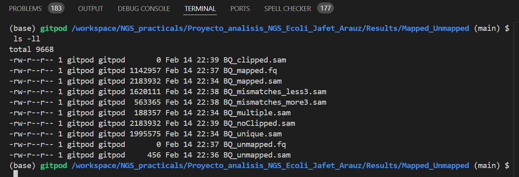

**Inspecionar las lecturas no mapeadas con BLAST y tomar capturas**

```bash
# Primero convertir a archivo Fasta para subirla la secuencia a BLAST
# Cambiar de directorio, crear carpeta para guardar los ouput y entrar a esa carpeta
cd "${st_path}/Results"
mkdir Unmapped_Fasta
cd Unmapped_Fasta

# Convertir a Fasta

#BQ_unmapped.fq
awk 'NR%4==1{print ">" substr($0,2)} NR%4==2{print $0}' \
    "$st_path/Results/Mapped_Unmapped/BQ_unmapped.fq" > "BQ_unmapped.fasta"

# verificar el resultado

ls -ll
```

**Dividir el archivo SAM original en un archivo que contenga lecturas alineadas** **con más de 3 desajustes y un archivo que contenga lecturas con menos de 3** **desajustes**

```bash
# Cambiar de directorio
cd "${st_path}/Results/Mapped_Unmapped"

# Extraer lecturas con MÁS de 3 desajustes
samtools view -Sh "$st_path/Results/Aligned_Sequences/BQ_cleaned.sam" | \
grep -E "NM:i:[4-9]\b|NM:i:[1-9][0-9]\b" > "BQ_mismatches_more3.sam"

# Extraer lecturas con 3 o MENOS desajustes
samtools view -Sh "$st_path/Results/Aligned_Sequences/BQ_cleaned.sam" | \
grep -E "NM:i:[0-3]\b" > "BQ_mismatches_less3.sam"

#verificar resultados
ls -ll
```

**Dividir el archivo SAM en un archivo que contenga lecturas recortadas** **y un archivo que contenga solo lecturas no recortadas.**

```bash
# Extraer lecturas recortadas (soft-clipped)
samtools view -Sh "$st_path/Results/Aligned_Sequences/BQ_cleaned.sam" | \
awk '$6 ~ /[0-9]+S/' > "BQ_clipped.sam"

# Extraer lecturas NO recortadas (sin soft-clipping)
samtools view -Sh "$st_path/Results/Aligned_Sequences/BQ_cleaned.sam" | \
awk '$6 !~ /[0-9]+S/' > "BQ_noClipped.sam"

# verificar resultado com este comando si ambos dan cero significa que
# esta bien todo,las lecturas están completamente alineadas sin recortes.

awk '$6 ~ /[0-9]+S/' BQ_mapped.sam | wc -l

awk '$6 ~ /[0-9]+H/' BQ_mapped.sam | wc -l
```

### 3.1 Respuestas a preguntas de la parte 3 del ejercicio

**¿Cómo puedes obtener el resultado de (b) utilizando Bowtie2 en su lugar?**

En primer lugar la herramineta adecuada para extraer las lecturas mapeadas y no mapeadas tomando como input el .sam original es samtools , pero como la pregunta es referida a como hacerlo con bowtie2 usando el .sam original al respuesta a esto es que no hay forma de hacerlo. Esto por que bowtie2 no usa el .sam original para hacerlo; si no que, si se le especifican en los parametros de alinemiento que lo haga, lo hace durante este proceso separando las lecturas mapeadas y no mapeadas en formato FASTQ y esta informacion ya no se encontrara en el .sam generado durante el alineamiento (al que llamamos .sam original) lo cual significa que se hace durante el alineamiento y no despues a como se hace con samtools, de hacerlo con Bowtie2 ya no se extraer la informacion de las lecturas mapeadas y no mapeadas con samtools usando el .sam original.

#### 3.1.1 *Esta seria la line de comando para hacerlo con Bowtie*

```bash
# Cambiar de directorio, crear carpeta para guardar los ouput y entrar a esa carpeta
cd "${st_path}/Results"
mkdir Mapped_Unmapped_Bowtie2
cd Mapped_Unmapped_Bowtie2

# Ejecutar Bowtie2 para obtener las secuencias mapeadas y no mapeadas
echo -e "\n##################################################################"
echo -e " Elaborado por Jafet Arauz | Iniciando alineamiento de BQ con Bowtie2..."
echo -e "##################################################################\n"

bowtie2 --very-sensitive --end-to-end --no-mixed --no-discordant -k 10 \
    -x "$st_path/Genomes_reference/AFPN02.1_merge" \
    -U "$st_path/Results/Secuences_Trimmed/BQ_cleaned.fq" \
    -S "BQ_cleaned.sam" \
    --un "BQ_cleaned_unmapped.fq" \
    --al "BQ_cleaned_mapped.fq" \
    2> "BQ_cleaned_bowtie_stats.txt"

echo -e "\n##################################################################"
echo -e " Alineamiento de BQ completado con éxito. Resultados guardados en: $(pwd)"
echo -e "##################################################################\n"

# Convertir a Fasta
#BQ_unmapped.fq
awk 'NR%4==1{print ">" substr($0,2)} NR%4==2{print $0}' \
    "$st_path/Results/Mapped_Unmapped_Bowtie2/BQ_cleaned_unmapped.fq" > "BQ_unmapped_Bowtie2.fasta"
```

#### 3.1.2 **¿cree que los desajustes son biológicamente relevantes? explicar**

Si son relevantes pero su importancia dependeran del contexto del analisis.En el alineamineto su interpretacion podria ser presencia de mutaciones o polimorfismos de un solo nucleotido, o quizas errores de secuenciacion. Si los desajustes se dan en zonas altamente conservadas podria sugerir errores tecnicos, pero si existiese un patron especifico en varias zonas podria ser indicio de variabilidad biologica. Lo recomendable es revisar las estadisticas despues del alineamiento y la visualizacion de los desajustes asi como hacer una comparacion con bases de datos. De comprobarse que son causdos por errores tecnicos se puden modificar los paramteros para hacerlos mas estrictos.

#### 3.1.3 **Inspeccione las lecturas no mapeadas y utilice BLAST para identificar su origen. Informe sus resultados**

Pero al hacerlo con Bowtie2, si se generaron secuencias no mapeadas. Esta con lo samtools no significa que samtools lo hiciera mal, solo que ambos tienen diferente fomar de extraer las lecturas mapeadas y no mapeadas, como Bowtie2 requirio ajustar los parametros para obtener esta informacion por eso etiqueto algunas secuencias como no mapeadas, asi que procedi a inspeccinarlas con BLAST para ver el origen de estas secuencias.

**A contiuacion las fotos de las busqueda en BLAST y un breve interpretacion**

#### 3.1.4 **Primera busqueda, con parametros generales en BLAST**

[figure not shown]

#### 3.1.5 **Segunda busqueda especificando parametros de comparacion con bacterias**

[figure not shown]

**Conclusion**

Al hacer la busqueda en BLAST las secuencias no mapeadas no mostraron coincidencias con otras bacterias en la base de Datos especifica. En cambio en comparacion se encontro similitud con ADN de humanos y primates lo cual sugiere posible contaminacion o artefactos de secuenciacion.

Ademas el usar parametros mas estrictos con Bowtie2 permite el poder detectar si hay precensia de contaminantes o no, por lo que aunque el alineamiento inicial salio bien es una buena practica ajustar los parametros despues para obtner las lecturas mapeadas y no mapeadas y poder analizarlas.